# Single-molecule analysis of the change in RNA Pol II binding frequency upon triptolide treatment

Kasit Chatsirisupachai

2024-06-21

# Introduction

In previous examples, we only analyse SMF data in the bulk level (i.e. average methylation). However, the actual advantage of SMF comes from the analysis at the ‘single-molecule’ level. With this type of analysis, we can assign a molecular state for each single DNA molecule in the sequencing data. Moreover, this will lead us to the ‘frequency’ of each molecular state across the population.

In this example, we will re-analyse a subset of data from the first SMF paper from the Krebs lab (Krebs *et al.*, *Mol. Cell*, 2017). This paper investigated the turnover of RNA polymerase II (Pol II) in *Drosophila* promoters. To study the binding of Pol II, each DNA molecule was assigned into one of the five promoter states (nucleosome, unbound, PIC, PIC.polII, and polII), based on the biology of known promoter motifs.

## Data

The data is the targeted amplicon dual-enzyme SMF of selected *Drosophila* promoters on S2 cell line, with or without triptolide (TRP) treatment, an inhibitor of transcription initiation. SMF library were sequenced in paired-end using Illumina platform. Once obtain the raw sequencing data, Fastq files were aligned to the *Drosophila* dm6 genome using `QuasR` package. Since this is an amplicon data, we do not remove duplicate reads.

# Pol II analysis

## Load libraries

```r
library(QuasR)
library(SingleMoleculeFootprinting)
library(BSgenome.Dmelanogaster.UCSC.dm6)
library(tidyverse)
```

```r
library(ggplot2)
library(here)
library(stringi)
```

## Create QuasR input file

Similar to the previous example, we will first create QuasR input file. All BAM files for this example are in the folder `/data/dataset_3_S2_amplicon_TRP`

```r
Qinput <- "/g/krebs/chatsiri/SMF_tutorial/analysis/example_3/Qinput_S2_DMSOvsTRP_subset.txt"
```

## Load the GRanges object containing promoters of interest

```r
TSSs <- readRDS("/g/krebs/chatsiri/SMF_tutorial/data/dataset_3_S2_amplicon_TRP/TSS_GRanges.rds")
print(TSSs)
```

```
## GRanges object with 36 ranges and 2 metadata columns:
##                  seqnames    ranges strand |     tx_id        gene_id
##                     <Rle> <IRanges>  <Rle> | <integer>    <character>
##      NM_164359.2    chr2L    107968      + |        24    NM_164359.2
##   NM_001299003.1    chr2L  14490862      + |      2242 NM_001299003.1
##   NM_001038776.3    chr2L    129243      - |      3387 NM_001038776.3
##   NM_001272903.1    chr2L    479683      - |      3458 NM_001272903.1
##   NM_001298741.1    chr2L   6423306      - |      4344 NM_001298741.1
##              ...      ...       ...    ... .       ...            ...
##      NM_079645.4    chr3R  15901380      - |     25867    NM_079645.4
##      NM_079659.4    chr3R  17119082      - |     26046    NM_079659.4
##      NM_079719.3    chr3R  21856264      - |     26693    NM_079719.3
##   NM_001276025.1    chr3R  25473057      - |     27246 NM_001276025.1
##   NM_001170289.2    chr3R  28540324      - |     27637 NM_001170289.2
##   -------
##   seqinfo: 1870 sequences (1 circular) from dm6 genome
```

## Call context methylation

As an example, we will first work on only one promoter region for now.

```r
MySample <- suppressMessages(readr::read_delim(Qinput, delim = "\t")[[2]])

genome <- BSgenome.Dmelanogaster.UCSC.dm6

# make cluster
cluObj <- makeForkCluster(nnodes = 4)

# define region of interest by extending the TSS to cover 500 bp (250 upstream and 250 downstream)
# select only one TSS: NM_080188.3
TSS <- TSSs[TSSs$gene_id == "NM_080188.3",]
gr <- resize(TSS, 500, fix = "center")

print(gr)
```

```
## GRanges object with 1 range and 2 metadata columns:
##               seqnames            ranges strand |     tx_id     gene_id
##                  <Rle>         <IRanges>  <Rle> | <integer> <character>
##   NM_080188.3    chr3R 12505538-12506037      + |     21275 NM_080188.3
##   -------
##   seqinfo: 1870 sequences (1 circular) from dm6 genome
```

```r
# Call context methylation
Methylation <- CallContextMethylation(sampleSheet = Qinput,
                                        sample = MySample,
                                        genome = genome,
                                        RegionOfInterest = gr,
                                        coverage = 20,
                                        ConvRate.thr = 0.2,
                                        returnSM = TRUE)
```

```
## Setting QuasR project
```

```
## all necessary alignment files found
```

```
## Calling methylation at all Cytosines
```

```
## checking if RegionOfInterest contains information at all
```

```
## Discard immediately the cytosines not covered in any sample
```

```
## Extracting single molecule matrix
```

```
## 0% of reads found with conversion rate below 0.2
## 0% of reads found with conversion rate below 0.2
```

```
## Subsetting Cytosines by permissive genomic context (GC, HCG)
```

```
## Collapsing strands
```

```
## 709 reads found mapping to the - strand, collapsing to +
```

```
## 704 reads found mapping to the - strand, collapsing to +
```

```
## 669 reads found mapping to the - strand, collapsing to +
```

```
## 666 reads found mapping to the - strand, collapsing to +
```

```
## Filtering Cs for coverage
```

```
## Detected experiment type: DE
```

```
## Subsetting Cytosines by strict genomic context (GCH, GCG, HCG) based on the detected experiment type: DE
```

```
## Merging matrixes
```

Unlike in previous example (`02_PEPC_vs_NEB`), we now set the parameter returnSM to `TRUE`. This will make the function return methylation status for each DNA molecule, in addition to the bulk average methylation level. Let’s take a look at the Methylation object.

The first object in Methylation contains the bulk average methylation level at each cytosine, similar to what we saw previously in the `02_PEPC_vs_NEB` example.

```r
print(Methylation[[1]])
```

```
## GRanges object with 32 ranges and 5 metadata columns:
##        seqnames    ranges strand | DMSO_DE_S2_Coverage DMSO_DE_S2_MethRate
##           <Rle> <IRanges>  <Rle> |           <integer>           <numeric>
##    [1]    chr3R  12505696      + |                 695            0.945324
##    [2]    chr3R  12505706      + |                 696            0.974138
##    [3]    chr3R  12505710      + |                 696            0.913793
##    [4]    chr3R  12505718      + |                 696            0.916667
##    [5]    chr3R  12505726      + |                 696            0.961207
##    ...      ...       ...    ... .                 ...                 ...
##   [28]    chr3R  12505879      + |                 708            0.806497
##   [29]    chr3R  12505889      + |                 707            0.758133
##   [30]    chr3R  12505921      + |                 707            0.345120
##   [31]    chr3R  12505940      + |                 707            0.237624
##   [32]    chr3R  12505956      + |                 699            0.258941
##        TRP_DE_S2_Coverage TRP_DE_S2_MethRate GenomicContext
##                 <integer>          <numeric>    <character>
##    [1]                655           0.943511            HCG
##    [2]                657           0.981735            GCH
##    [3]                657           0.945205            HCG
##    [4]                658           0.933131            HCG
##    [5]                658           0.977204            GCG
##    ...                ...                ...            ...
##   [28]                668           0.770958            GCH
##   [29]                669           0.678625            GCH
##   [30]                666           0.298799            GCH
##   [31]                658           0.209726            GCH
##   [32]                653           0.261868            GCH
##   -------
##   seqinfo: 1870 sequences (1 circular) from dm6 genome
```

Here, we can already plot the average SMF signal, to see if TRP treatment actually reduce paused Pol II footprint.

```
## No sorted reads passed...plotting counts from all reads
```

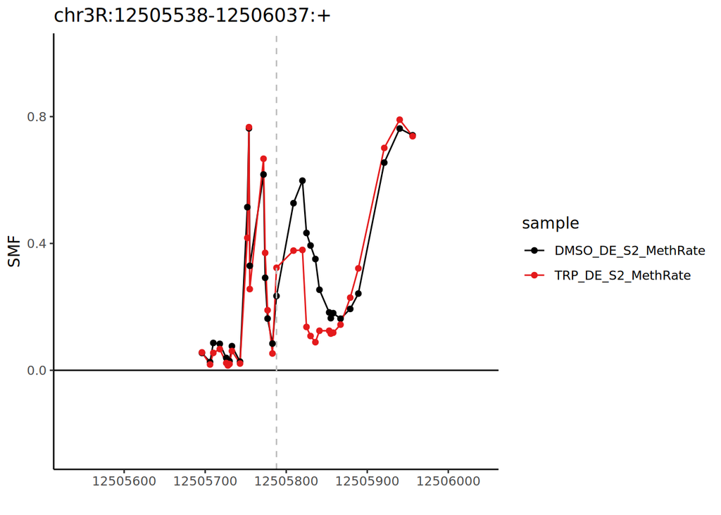

```r
PlotAvgSMF(MethGR = Methylation[[1]],
           RegionOfInterest = gr) +
  geom_vline(xintercept = 12505788, linetype="dashed", color = "grey")
```

From the average plot, we can observe a reduction of Pol II footprint at the pausing site (~30-50 nucleotides downstream of the TSS). We next ask, can we go beyond the bulk analysis and assign a promoter state to each single-molecule of DNA?

## Single-molecule sorting and quantification of promoter state frequencies

We will assign each DNA molecule to a promoter state (unassigned, nucleosome, unbound, PIC, PIC.polII, and polII). These promoter states can be dictated by a four-bin methylation pattern. The bins and their relative location to the TSS are: 1. upstream [-58:-43], 2. TATA-box [-36:-22], 3. paused Pol II [28:47], and 4. downstream [54:69]

We will define an average cytosine methylation status in each bin. Thus, a vector of 4 can be derived. For example, if there is only a Pol II bound at the paused Pol II site, and the other bins are unoccupied, we will encode a patter `1101`. There are 16 patters in total ($2^4$.)

First, let’s look at the second object in the Methylation object from above. This represents a sparse matrix containing single-molecule methylation status for each DNA molecule. Rows are DNA molecules, while columns are positions of each cytosine. `1` means unmethylated cytosine (i.e. “protected”) and `2` means methylated cytosine (i.e. accessible).

```r
# DMSO
print(head(Methylation[[2]]$DMSO_DE_S2))
```

```
## 6 x 32 sparse Matrix of class "dgCMatrix"
```

```
##   [[ suppressing 32 column names '12505696', '12505706', '12505710' ... ]]
```

```
##
## SRR3133278.1000508 2 2 2 2 2 2 2 2 2 1 1 1 1 1 2 2 1 1 1 2 2 2 2 2 2 2 2 2 2 1
## SRR3133278.1001604 2 2 2 2 2 2 2 2 2 2 1 1 1 1 2 2 2 2 1 1 1 1 1 1 1 1 2 2 1 2
## SRR3133278.1003005 2 2 2 2 2 2 2 2 2 1 1 2 1 2 2 2 2 2 2 2 2 2 2 2 2 2 2 2 2 2
## SRR3133278.1003185 . . . . . . . . . . . . 2 2 2 2 2 2 2 2 2 2 2 2 2 2 2 2 2 2
## SRR3133278.1003699 2 2 2 2 2 2 2 2 2 2 1 2 2 2 2 2 2 1 1 1 1 2 2 2 2 2 2 2 2 2
## SRR3133278.1004721 2 2 2 2 2 2 2 2 2 2 2 2 2 2 2 2 2 2 2 2 2 2 2 2 2 2 2 2 2 2
##
## SRR3133278.1000508 1 1
## SRR3133278.1001604 2 2
## SRR3133278.1003005 2 2
## SRR3133278.1003185 1 1
## SRR3133278.1003699 2 2
## SRR3133278.1004721 2 2
```

```r
# TRP
print(head(Methylation[[2]]$TRP_DE_S2))
```

```
## 6 x 32 sparse Matrix of class "dgCMatrix"
```

```
##   [[ suppressing 32 column names '12505696', '12505706', '12505710' ... ]]
```

```
##
## SRR3133272.1010080 2 2 2 2 2 2 2 2 2 1 1 2 1 2 2 2 2 2 2 2 2 2 2 2 2 2 2 2 2 2
## SRR3133272.1019667 2 2 2 2 2 2 2 2 2 2 1 2 1 1 2 2 1 1 1 1 2 2 2 2 2 2 2 2 1 1
## SRR3133272.1035614 2 2 2 2 2 2 2 2 2 2 1 2 1 1 1 2 1 1 1 1 2 2 2 2 2 2 2 2 2 1
## SRR3133272.1040332 1 2 2 2 2 2 2 2 2 1 1 2 1 1 2 2 1 1 1 2 2 2 2 2 2 2 2 2 2 1
## SRR3133272.1043879 2 2 2 2 2 2 2 2 2 1 1 2 1 2 2 2 2 2 2 2 2 1 2 2 1 1 1 1 1 1
## SRR3133272.1044946 2 2 2 2 2 2 1 2 2 2 2 2 2 2 2 2 2 2 1 1 2 1 2 1 1 1 1 1 1 1
##
## SRR3133272.1010080 2 1
## SRR3133272.1019667 1 1
## SRR3133272.1035614 1 1
## SRR3133272.1040332 . .
## SRR3133272.1043879 1 2
## SRR3133272.1044946 1 2
```

Here, we have to define the bin positions to the promoter we are working with. We can use the function `MakeBins` to do the job. As some promoters are located on the minus strand, we have to take this into account. (Yet, our example promoter (NM_080188.3) is on the plus strand)

```r
BinsCoordinates <- MakeBins(RegionsOfInterest = TSS, BinType = "Promoter", StrandAware = TRUE)
```

```
## Designing sorting bins
```

```r
print(BinsCoordinates)
```

```
## GRanges object with 4 ranges and 1 metadata column:
##               seqnames            ranges strand |        name
##                  <Rle>         <IRanges>  <Rle> | <character>
##   NM_080188.3    chr3R 12505730-12505745      + |          up
##   NM_080188.3    chr3R 12505752-12505766      + |        TATA
##   NM_080188.3    chr3R 12505816-12505835      + |       PolII
##   NM_080188.3    chr3R 12505842-12505857      + |        down
##   -------
##   seqinfo: 1870 sequences (1 circular) from dm6 genome
```

```r
strand <- unique(as.character(strand(BinsCoordinates)))
print(strand)
```

```
## [1] "+"
```

Next, we can sort each read into one of the 16 patters. We will use the `SortedReads` function for this purpose.

```r
SortedReads <- lapply(Methylation[[2]], SortReads, BinsCoordinates = BinsCoordinates,
                      coverage = 20, strand = strand)
```

```
## Subsetting those reads that cover all bins
```

```
## Summarizing reads into patterns
```

```
## Splitting reads by pattern
```

```
## Subsetting those reads that cover all bins
```

```
## Summarizing reads into patterns
```

```
## Splitting reads by pattern
```

```r
# How many reads in each pattern?
# DMSO
lapply(SortedReads$DMSO_DE_S2, length) %>% unlist() %>% print()
```

```
## 0000 0010 0011 0110 0111 1000 1001 1010 1011 1100 1101 1110 1111
##    5    1    7    1    1   40  132   28  184   30   92   38  139
```

```r
# TRP
lapply(SortedReads$TRP_DE_S2, length) %>% unlist() %>% print()
```

```
## 0000 0011 0110 0111 1000 1001 1010 1011 1100 1101 1110 1111
##    2    1    1    1   14   31   34  243   13   29   36  254
```

```r
# create a dataframe of state frequencies
StateFrequency_tbl <- StateQuantification(SortedReads = SortedReads, states = NULL)
print(StateFrequency_tbl)
```

```
## # A tibble: 26 × 4
##    Sample     State Counts  Freqs
##    <chr>      <chr>  <int>  <dbl>
##  1 DMSO_DE_S2 0000       5  0.716
##  2 DMSO_DE_S2 0010       1  0.143
##  3 DMSO_DE_S2 0011       7  1.00
##  4 DMSO_DE_S2 0110       1  0.143
##  5 DMSO_DE_S2 0111       1  0.143
##  6 DMSO_DE_S2 1000      40  5.73
##  7 DMSO_DE_S2 1001     132 18.9
##  8 DMSO_DE_S2 1010      28  4.01
##  9 DMSO_DE_S2 1011     184 26.4
## 10 DMSO_DE_S2 1100      30  4.30
## # ℹ 16 more rows
```

Now, it’s time to assign promoter states to bin patterns. Here, we need a bit of prior biological knowledge.

```r
promoter_states <- list(unassigned = c("0101", "0110", "1010"),
                        nucleosome = c("0000", "0001", "0010", "0011", "0100", "1000", "1100"),
                        unbound = c("0111", "1110", "1111"),
                        PIC = c("1011"),
                        PIC.polII = c("1001"),
                        polII = c("1101"))

promoter_statesF <- as.factor(unlist(lapply(seq_along(promoter_states), function(i){
  rep(names(promoter_states[i]), length(promoter_states[[i]]))}))[order(unlist(promoter_states))])

promoter_statesF <- factor(promoter_statesF, levels = names(promoter_states))
```

Finally, we will quantify promoter state frequencies.

```r
# All 16 possible states
allPos <- expand.grid(c(0,1), c(0,1), c(0,1), c(0,1))
states <- names(table(apply(allPos, 1, function(x){(paste(as.character((x)), collapse = ""))})))
print(states)
```

```
##  [1] "0000" "0001" "0010" "0011" "0100" "0101" "0110" "0111" "1000" "1001"
## [11] "1010" "1011" "1100" "1101" "1110" "1111"
```

```r
# our two samples
samples <- unique(StateFrequency_tbl$Sample)

# working on each sample
stateM_list <- lapply(samples, function(sample){

  print(paste0("Creating state matrix for: ", sample))

  # subset df to select only a sample we are working with
  StateFrequency_sample <- StateFrequency_tbl[StateFrequency_tbl$Sample == sample,]

  # create a matrix to store state frequencies
  stateM <- matrix(nrow = length(TSS), ncol = length(states))
  rownames(stateM) <- names(TSS)
  colnames(stateM) <- states

  # add frequencies to the state matrix
  for(state in StateFrequency_sample$State){
    stateM[, state] <- StateFrequency_sample[StateFrequency_sample$State == state, ]$Freqs
  }

  stateM[is.na(stateM)] <- 0

  return(stateM)
})
```

```
## [1] "Creating state matrix for: DMSO_DE_S2"
## [1] "Creating state matrix for: TRP_DE_S2"
```

```r
# Collapse state matrix to promoter states
collapse_states <- function(state_matrix, promoter_statesF){
  return(t(apply(state_matrix, 1, function(x){tapply(x, promoter_statesF, sum)})))
}

grouped_freq_mats <- lapply(stateM_list, collapse_states, promoter_statesF = promoter_statesF)
print(grouped_freq_mats)
```

```
## [[1]]
##             unassigned nucleosome  unbound      PIC PIC.polII    polII
## NM_080188.3   4.154728   11.89112 25.50143 26.36103  18.91117 13.18052
##
## [[2]]
##             unassigned nucleosome  unbound      PIC PIC.polII    polII
## NM_080188.3   5.311077   4.552352 44.15781 36.87405  4.704097 4.400607
```

You can see that Pol II binding frequency decreased upon TRP treatment.

We can plot SMF signal again, this time with a single-molecule stack and a quantification bar.

```
## Producing average SMF plot
```

```
## Sorted reads passed along with SM matrix...plotting only counts relevant to sorting
```

```
## Producing Single Molecule stacks
```

```
## Producing state quantification plots
```

```
## Promoter state quantification with Strand: +
```

```
## Inferring sorting was performed by promoter states
```

```
## Combining plots
```

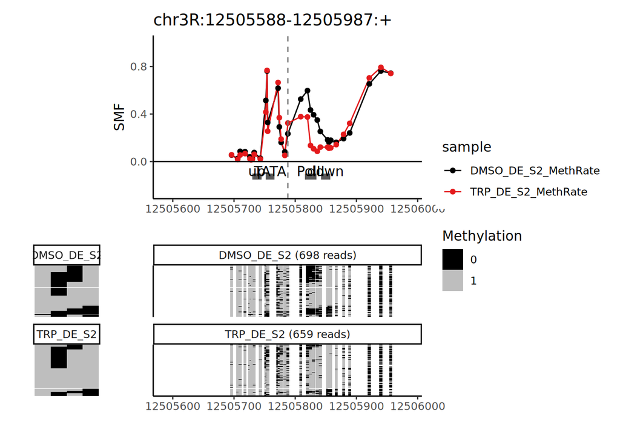

```r
# add column TF in the BinsCoordinates object (due to the argument in the plotting function)
BinsCoordinates$TF <- BinsCoordinates$name

# Plotting function (you can try to unpack this function!)
SingleMoleculeFootprinting::PlotSingleSiteSMF(Methylation = Methylation,
                                              RegionOfInterest = resize(TSS, width = 400, fix = "center"),
                                              TFBSs = BinsCoordinates,
                                              sorting.strategy = "promoter",
                                              SortedReads = SortedReads)
```

## Can we work on multiple promoters simultaneously?

Let’s go back to the `CallContextMethylation` step. Instead of working on one promoter, we can write a function to work on multiple promoters in parallel.

```r
# Create a methylation calling windows across all 36 promoters
gr <- resize(TSSs, 500, fix = "center")
print(gr)
```

```
## GRanges object with 36 ranges and 2 metadata columns:
##                  seqnames            ranges strand |     tx_id        gene_id
##                     <Rle>         <IRanges>  <Rle> | <integer>    <character>
##      NM_164359.2    chr2L     107718-108217      + |        24    NM_164359.2
##   NM_001299003.1    chr2L 14490612-14491111      + |      2242 NM_001299003.1
##   NM_001038776.3    chr2L     128993-129492      - |      3387 NM_001038776.3
##   NM_001272903.1    chr2L     479433-479932      - |      3458 NM_001272903.1
##   NM_001298741.1    chr2L   6423056-6423555      - |      4344 NM_001298741.1
##              ...      ...               ...    ... .       ...            ...
##      NM_079645.4    chr3R 15901130-15901629      - |     25867    NM_079645.4
##      NM_079659.4    chr3R 17118832-17119331      - |     26046    NM_079659.4
##      NM_079719.3    chr3R 21856014-21856513      - |     26693    NM_079719.3
##   NM_001276025.1    chr3R 25472807-25473306      - |     27246 NM_001276025.1
##   NM_001170289.2    chr3R 28540074-28540573      - |     27637 NM_001170289.2
##   -------
##   seqinfo: 1870 sequences (1 circular) from dm6 genome
```

```r
# Call context methylation and sorting in parallel
# note that the code below was modified from the wrapper function `SortReadsByPromoter_MultiSiteWrapper` for the purpose of this training. The actual function `SortReadsByPromoter_MultiSiteWrapper` is very useful for the genome-wide analysis, please feel free to have a look.

# this would take some time to run.
SortedReads <- parallel::mclapply(seq_along(gr), function(i) {
  CurrentWindow <- gr[i]
  print(paste0("Working on: promoter ", i))
  ExperimentType <- suppressMessages(SingleMoleculeFootprinting::DetectExperimentType(Samples = MySample))
  Methylation <- CallContextMethylation(sampleSheet = Qinput,
                                        sample = MySample,
                                        genome = genome,
                                        RegionOfInterest = CurrentWindow,
                                        coverage = 20,
                                        ConvRate.thr = 0.2,
                                        returnSM = TRUE)
  SortedReads_window <- list(SortReadsBySinglePromoter(MethSM = Methylation[[2]],
                                                       TSS = TSSs[i],
                                                       coverage = 20))
  names(SortedReads_window) <- names(TSSs[i])

  return(SortedReads_window)
  }, mc.cores = 8)

SortedReads <- unlist(SortedReads, recursive = FALSE)

# Calculate state frequencies
StateFrequency_tbl <- Reduce(rbind, parallel::mclapply(seq_along(SortedReads),
        function(i) {
            StateQuantification_tbl = StateQuantification(SortedReads = SortedReads[[i]],
                states = NULL)
            StateQuantification_tbl$TSS = names(SortedReads[i])
            StateQuantification_tbl
        }, mc.cores = 4))

StateFrequency_tbl <- drop_na(StateFrequency_tbl)
```

Again, the next step is to assign 4-bin states into promoter states. As previously we only work on one promoter, can we modify the codes to work on all promoters?

```r
# All 16 possible states
allPos <- expand.grid(c(0,1), c(0,1), c(0,1), c(0,1))
states <- names(table(apply(allPos, 1, function(x){(paste(as.character((x)), collapse = ""))})))
print(states)
```

```
##  [1] "0000" "0001" "0010" "0011" "0100" "0101" "0110" "0111" "1000" "1001"
## [11] "1010" "1011" "1100" "1101" "1110" "1111"
```

```r
# our two samples
samples <- unique(StateFrequency_tbl$Sample)

###################################
# select only promoters that are present in both samples
prom_DMSO <- StateFrequency_tbl %>% filter(Sample == "DMSO_DE_S2") %>% select(TSS) %>% unique() %>% unlist()

prom_TRP <- StateFrequency_tbl %>% filter(Sample == "TRP_DE_S2") %>% select(TSS) %>% unique() %>% unlist()

shared_prom <- prom_TRP[prom_TRP %in% prom_DMSO]

# filter to keep promoters that are in both samples
StateFrequency_tbl <- StateFrequency_tbl %>% filter(TSS %in% shared_prom)
###################################

# working on each sample
stateM_list <- lapply(samples, function(sample){

  print(paste0("Creating state matrix for: ", sample))

  # subset df to select only a sample we are working with
  StateFrequency_sample <- StateFrequency_tbl %>% filter(Sample == sample)

  # create a matrix to store state frequencies
  stateM <- matrix(nrow = length(unique(StateFrequency_tbl$TSS)), ncol = length(states))
  rownames(stateM) <- unique(StateFrequency_tbl$TSS)
  colnames(stateM) <- states

  # add frequencies to the state matrix
  for(promoter in unique(StateFrequency_tbl$TSS)){
    tmp <- StateFrequency_sample[StateFrequency_sample$TSS == promoter,]
    for(state in unique(tmp$State)){
    stateM[promoter, state] <- tmp[tmp$State == state, ]$Freqs
    }
  }

  stateM[is.na(stateM)] <- 0

  return(stateM)
})
```

```
## [1] "Creating state matrix for: DMSO_DE_S2"
## [1] "Creating state matrix for: TRP_DE_S2"
```

```r
# Collapse state matrix to promoter states
collapse_states <- function(state_matrix, promoter_statesF){
  return(t(apply(state_matrix, 1, function(x){tapply(x, promoter_statesF, sum)})))
}

grouped_freq_mats <- lapply(stateM_list, collapse_states, promoter_statesF = promoter_statesF)

names(grouped_freq_mats) <- c("DMSO", "TRP")
```

Finally, it’s always a good idea to plot. So, we will make a boxplot showing a decrease of Pol II binding frequency upon TRP treatment.

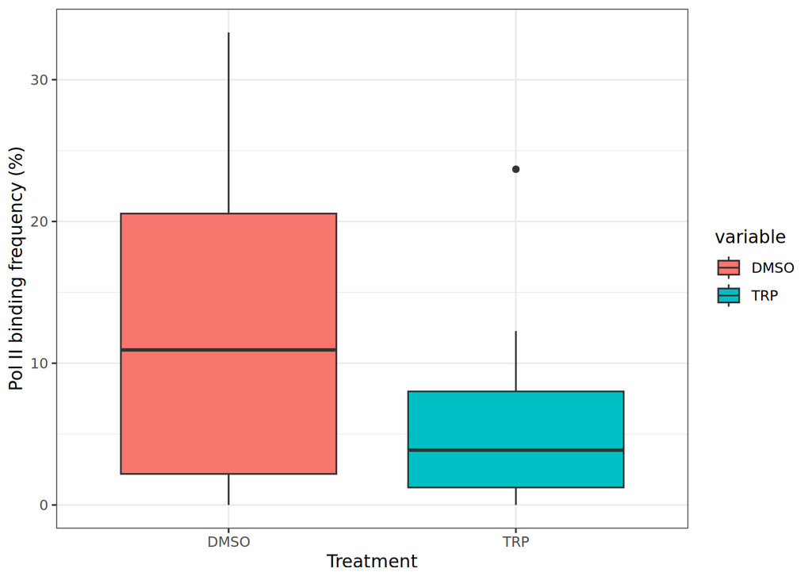

```r
DMSO <- as.data.frame(grouped_freq_mats$DMSO)
DMSO$polII_all <- DMSO$PIC.polII + DMSO$polII

TRP <- as.data.frame(grouped_freq_mats$TRP)
TRP$polII_all <- TRP$PIC.polII + TRP$polII

plot_df <- data.frame(DMSO = DMSO$polII_all, TRP = TRP$polII_all)
plot_df <- reshape2::melt(plot_df)
ggplot(plot_df, aes(x = variable, y = value, fill = variable)) +
  geom_boxplot() +
  xlab("Treatment") + ylab("Pol II binding frequency (%)") +
  theme_bw()
```

## Bonus: Genome-wide quantification of promoter states

Of course, we can use SMF to quantify promoter states across the genome. Here, I reanalysed genome-wide data from S2 *Drosophila* cells (Krebs *et al.*, *Mol. Cell*, 2017). I stored promoter state frequency in an rds object. I further analysed Pol II ChIP-seq, PRO-seq, DNase-seq, and MNase-seq from publicly available data sets. In the below chunk of code, we will correlate different data types with promoter state frequencies obtained from SMF.

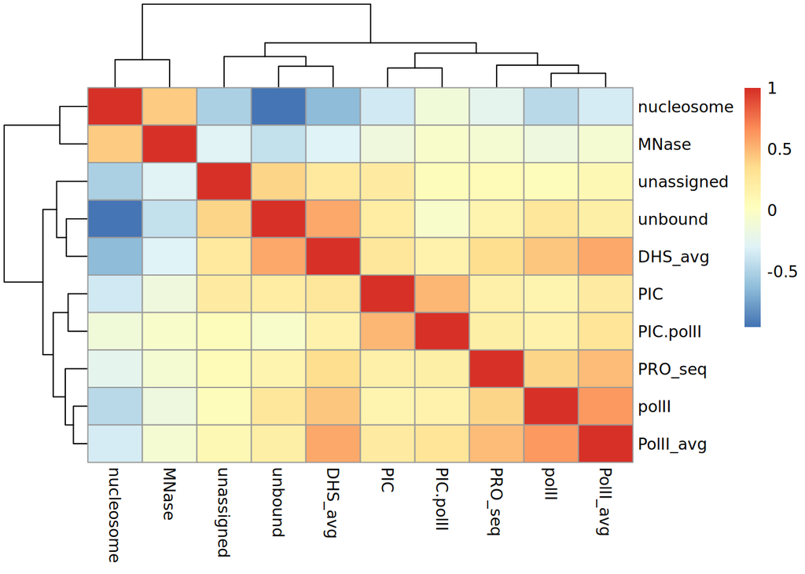

```r
# Load different data sets
SMF_state_freq <- readRDS("/g/krebs/chatsiri/SMF_tutorial/data/dataset_3_S2_amplicon_TRP/DM_S2_DE_promoter_states_freq_matrix_avg_downstream_bins.rds")
ChIP_seq <- readRDS("/g/krebs/chatsiri/SMF_tutorial/data/dataset_3_S2_amplicon_TRP/S2_PolII_ChIP_seq.rds")
PRO_seq <- readRDS("/g/krebs/chatsiri/SMF_tutorial/data/dataset_3_S2_amplicon_TRP/S2_PRO_seq.rds")
MNase_seq <- readRDS("/g/krebs/chatsiri/SMF_tutorial/data/dataset_3_S2_amplicon_TRP/S2_MNase.rds")
DHS_seq <- readRDS("/g/krebs/chatsiri/SMF_tutorial/data/dataset_3_S2_amplicon_TRP/S2_DHS.rds")


### Join data frames
SMF_state_freq$row.names <- row.names(SMF_state_freq)
ChIP_seq$row.names <- row.names(ChIP_seq)
MNase_seq$row.names <- row.names(MNase_seq)
PRO_seq$row.names <- row.names(PRO_seq)
DHS_seq$row.names <- row.names(DHS_seq)

# put all data frames into list
df_list <- list(SMF_state_freq,
                ChIP_seq,
                MNase_seq,
                PRO_seq,
                DHS_seq)
# merge all data frames in the list
df_list %>% reduce(full_join,
                   by = "row.names") -> merged_df

merged_df$row.names <- NULL

merged_df %>% drop_na() -> merged_df

plot_df <- cor(merged_df)
### Heatmap
pheatmap::pheatmap(plot_df)
```